# Illustration to homework answers

Yuning Dong

2024-12-09

# —–Homework0-2024.09.09—–

## Questions:

Use knitr to produce at least 3 examples that mix with figures and/or tables, and mathematical formulas better.

## Answers:

### Example 1: linear regression of rock data

Description: rock.csv dataset contains 48 samples of air permeability(perm), total pore area(pore), total pore perimeter(peri) and shape. Perform linear regression with perm as dependent variable.

pairwise scatter plots between variables:

```r
library(TSA)
```

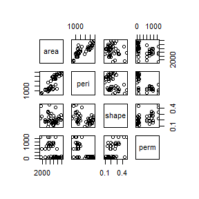

```r
plot(rock)
```

Perform linear regression with perm representing y, $x_1$,$x_2$,$x_3$ representing area, peri and shape respectively. Then we get the following model expression:
$$y_i = \beta_0+\beta_1x_{i1}1+\beta_2x_{i2}+\beta_3x_{i3}+\epsilon_i,
i=1,2,...48.$$

```r
r = lm(perm~.,rock)
summary(r)
```

```
##
## Call:
## lm(formula = perm ~ ., data = rock)
##
## Residuals:
##     Min      1Q  Median      3Q     Max
## -750.26  -59.57   10.66  100.25  620.91
##
## Coefficients:
##              Estimate Std. Error t value Pr(>|t|)
## (Intercept) 485.61797  158.40826   3.066 0.003705 **
## area          0.09133    0.02499   3.654 0.000684 ***
## peri         -0.34402    0.05111  -6.731 2.84e-08 ***
## shape       899.06926  506.95098   1.773 0.083070 .
## ---
## Signif. codes:  0 '***' 0.001 '**' 0.01 '*' 0.05 '.' 0.1 ' ' 1
##
## Residual standard error: 246 on 44 degrees of freedom
## Multiple R-squared:  0.7044, Adjusted R-squared:  0.6843
## F-statistic: 34.95 on 3 and 44 DF,  p-value: 1.033e-11
```

Thus, the fitted least square regression line is
$$y = 485.618 + 0.091x_1 - 0.344x_2+899.069x_3.$$
Use qq plot to check normality:

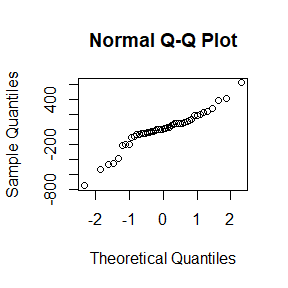

```r
qqnorm(r$res)
```

### Example 2: Use the polynomial equation to judge stationarity.

For an AR(4)process:$Y_t=1.2Y_{t-1}-0.6Y_{t-2}+0.2Y_{t-3}-0.05Y_{t-4}+e_t$,check its stationarity.

```r
p2=c(1,-1.2,0.6,-0.2,0.05)
r2 = polyroot(p2)
r2
```

```
## [1] 1.6435943+0.553774i 1.6435943-0.553774i 0.3564057-2.553774i
## [4] 0.3564057+2.553774i
```

The module length of r2 is greater than 1, so this Ar(4) process is stationary.

Plot ACF function of AR(4).

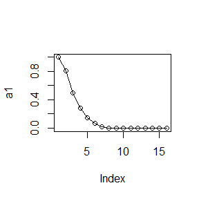

```r
a1=ARMAacf(ar=c(1.2,-0.6,0.2,-0.05),lag=15)
plot(a1,type='o')
```

### Example3: ARMA(p,q) model recognition of time series.

Simulate ARMA(1,1) model with $\phi=0.6$,$\theta=-0.3$. First, the time series plot is:

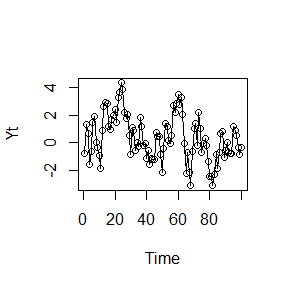

```r
data(arma11.s)
plot(arma11.s,type='o',ylab=expression(Yt))
```

Second, plot the sample ACF of arma(1,1).

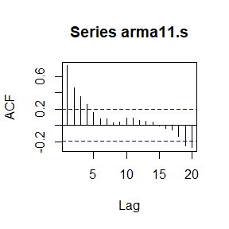

```r
acf(arma11.s)
```

Last, plot the sample PACF of arma(1,1).

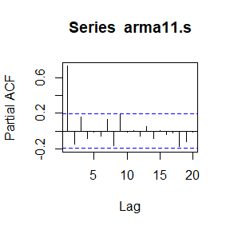

```r
pacf(arma11.s)
```

# —–Homework1-2024.09.14—–

### Question 1: Exercise 3.4 from 《Statistical Computing with R》

The Rayleigh density [156, Ch. 18] is $f\ (x) = \frac{x}{\sigma^2} e ^ {-x^2 / (2 \sigma^2)}$

Develop an algorithm to generate random samples from a Rayleigh(σ) distribution. Generate Rayleigh(σ) samples for several choices of $\sigma >0$ and check that the mode of the generated samples is close to the theoretical mode $\sigma$ (check the histogram).

### Answer for Question 1:

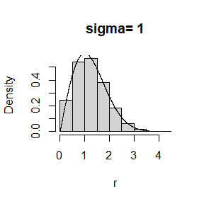

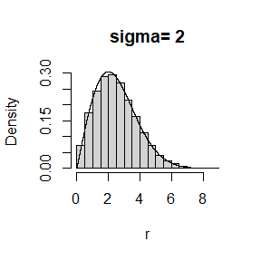

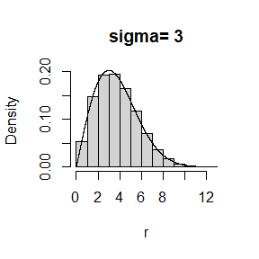

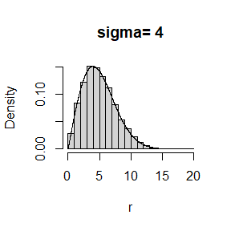

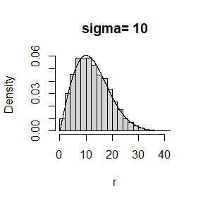

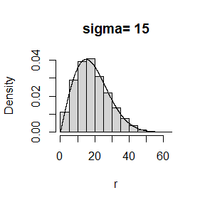

```r
sigma = c(1,2,3,4,10,15) #选取6个sigma
for(i in 1:length(sigma)){
  x1 = rnorm(1e4,0,sigma[i]) # 1000个服从正态分布的随机数
  x2 = rnorm(1e4,0,sigma[i]) # 两个独立同正态分布的随机向量
  r = (x1^2+x2^2)^0.5 # 生成服从Rayleigh分布的随机数
  hist(r,prob=TRUE, main = paste('sigma=',sigma[i]))   # 样本直方图

  x = seq(0,4*sigma[i],length.out=1e4)
  f = (x/sigma[i]^2)*exp(-(x^2)/(2*sigma[i]^2))
  lines(x,f) # 密度函数
}
```

### Question 2: Exercise 3.11 from 《Statistical Computing with R》

Generate a random sample of size 1000 from a normal location mixture. The components of the mixture have N(0,1) and N(3,1) distributions with mixing probabilities p1 and p2 =1− p1. Graph the histogram of the sample with density superimposed, for p1 =0.75. Repeat with different values for p1 and observe whether the empirical distribution of the mixture appears to be bimodal. Make a conjecture about the values of p1 that produce bimodal mixtures.

### Answer for QUestion 2:

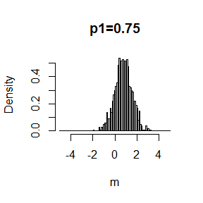

```r
pp = seq(0,1,0.05)
p = 0.75
x1 = rnorm(1000,0,1)
x2 = rnorm(1000,3,1)
m = p*x1+(1-p)*x2   #N(0,1)和N(3,1)分布的混合
hist(m,prob=TRUE,breaks = seq(-5,5,length.out=100),main = 'p1=0.75')         #当p=0.75时直方图
```

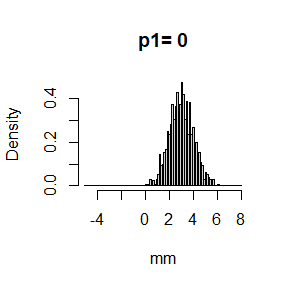

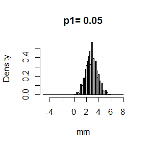

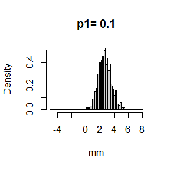

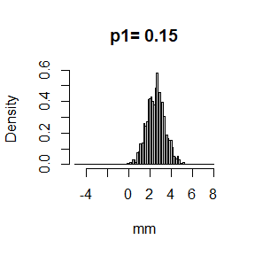

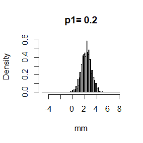

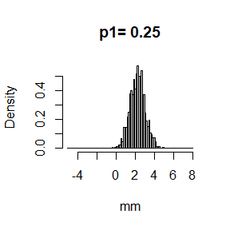

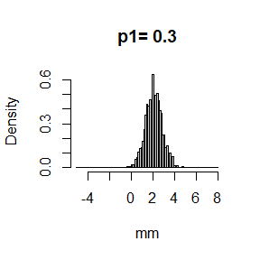

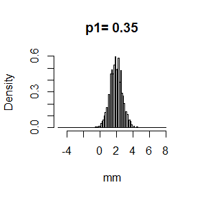

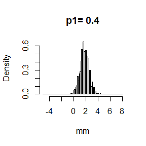

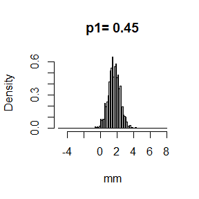

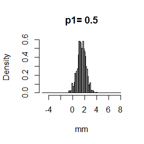

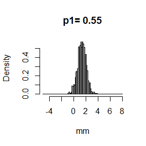

[9 more figures not shown]

```r
for(i in 1:length(pp)){
  mm = pp[i]*x1+(1-pp[i])*x2 # 不同p值下的直方图
  hist(mm,prob = TRUE, breaks = seq(-5,8,length.out = 100),main = paste('p1=',pp[i]))
}
```

### Question 3: Exercise 3.20 from 《Statistical Computing with R》

### Answer for Question 3:

```r
lambda = 5
shape = 2
scale = 4
size = 10000
eps = 0.1
xss = numeric(1e4)  # 初始化
ns = numeric(1e4)
t = 10

n = qpois(1-eps, lambda = lambda * t) #泊松过程：次数

# 生成服从泊松过程的Nt：
for(i in 1:size){

  Tn = rexp(1000, lambda) #  到达时间间隔为参数lambda的指数分布
  Sn = cumsum(Tn) # 累计求和
  ns[i] = min(which(Sn > t)) - 1

}

# 泊松-伽马过程：
xss = sapply(ns, function (n) {
  ys = c(rgamma(n = n, shape = shape, scale = scale))
  sum(ys[1:n])
})

means = mean(xss) # 样本均值和样本方差
vars = var(xss)

meant = lambda * t * shape * scale #理论均值和方差
vart = (shape + 1) * shape * scale^2

means;meant;vars;vart
```

```
## [1] 399.4201
```

```
## [1] 400
```

```
## [1] 4801.468
```

```
## [1] 96
```

其中，理论均值为meant=400，样本均值means与之相近。理论方差为vart=96，样本方差vars的数值较大。

# —–Homework2-2024.09.23—–

### Question 1: Exercise 5.4 from 《Statistical Computing with R》

Write a function to compute a Monte Carlo estimate of the Beta(3,3) cdf, and use the function to estimate F(x) for x = 0.1, 0.2,…, 0.9. Compare the estimates with the values returned by the pbeta function in R.

### Answer for question 1:

The pdf of Beta distribution with parameters a and b is: $f(x;a,b)=\frac{1}{B(a,b)}x^{a-1}(1-x)^{b-1}$, where $B(a,b)=\int_{0}^{1}x^{a-1}(1-x)^{b-1}dx$, $0<x<1$. Set $B(a,b)=\int_{0}^{1}t^{a-1}(1-t)^{b-1}dt =b$, $t$~$U(0,1)$. We need to solve $F(x)=\frac{1}{b}\int_{0}^{x}u^{2}(1-u)^{2}du=\frac{1}{b}E_U[xu^{2}(1-u)^{2}]$, where $0<x<1$,$U$~$U(0,x)$, and $a=b=3$.

```r
m = 1e5 #times of simulations
t = runif(m)
b = mean(t^2*(1-t)^2) #calculate the constant B(3,3)
for(x in seq(0.1,0.9,0.1)){
  u = runif(m,0,x)
  theta.hat = mean(x*u^2*(1-u)^2)/b
  theta.t = pbeta(x,3,3)
  print(c(theta.hat,theta.t, theta.hat/theta.t))

}
```

```
## [1] 0.008536076 0.008560000 0.997205194
## [1] 0.05783956 0.05792000 0.99861113
## [1] 0.1631388 0.1630800 1.0003603
## [1] 0.3173962 0.3174400 0.9998621
## [1] 0.5010951 0.5000000 1.0021902
## [1] 0.6827404 0.6825600 1.0002643
## [1] 0.8352551 0.8369200 0.9980107
## [1] 0.9434948 0.9420800 1.0015018
## [1] 0.9927351 0.9914400 1.0013062
```

### Question 2: Exercise 5.9 from 《Statistical Computing with R》

The Rayleigh density [156, (18.76)] is $f(x) = \frac{x}{\sigma^2}e^{-x^2/(2\sigma^2)}, x\geq0, \sigma>0.$ Implement a function to generate samples from a Rayleigh(σ) distribution, using antithetic variables. What is the percent reduction in variance of$\frac{X+X'}{2}$ compared with $\frac{X_1+X_2}{2}$ for independent X1, X2?

### Answer for question 2:

```r
sigma2 = 4
MC.Phi <- function(x, R = 10000, antithetic = FALSE) {
  u <- runif(R/2)
  if (antithetic) v <- 1 - u else v <- runif(R/2)
  u <- c(u, v)
  g <- x * exp(-(u * x)^2 / 2*sigma2) # x*u ~ U(0,x)
  cdf <- mean(g) / sigma2
  cdf
}

m <- 1000
MC1 <- MC2 <- numeric(m)
for (x in seq(1,10)){
  for (i in 1:m){
    MC1[i] <- MC.Phi(x, R = 1000, antithetic = FALSE)
    MC2[i] <- MC.Phi(x, R = 1000, antithetic = TRUE)
  }
  print(c(sd(MC1),sd(MC2),sd(MC2)/sd(MC1)))
}
```

```
## [1] 0.0022593375 0.0001158749 0.0512870983
## [1] 0.005516777 0.002828583 0.512723878
## [1] 0.007774799 0.006026139 0.775086193
## [1] 0.009157952 0.007972504 0.870555293
## [1] 0.010524260 0.009566115 0.908958433
## [1] 0.01207427 0.01051564 0.87091276
## [1] 0.01259550 0.01200964 0.95348665
## [1] 0.01445862 0.01332743 0.92176429
## [1] 0.01515744 0.01448344 0.95553334
## [1] 0.01559821 0.01468366 0.94136806
```

### Question 3: Exercise 5.13 from 《Statistical Computing with R》

Find two importance functions $f_1$ and $f_2$ that are supported on (1,$\infty$) and are ‘close’ to $g(x)=\frac{x^2}{\sqrt{2\pi}}e^{-x^2/2}, x>1.$ Which of your two importance functions should produce the smaller variance in estimating $\int_{1}^{\infty}\frac{x^2}{\sqrt{2\pi}}e^{-x^2/2}dx$ by importance sampling? Explain why.

### Answer for question 3:

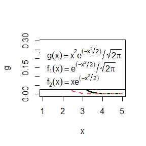

```r
x = seq(1,5,0.1)
g = x^2*exp(-x^2/2)/sqrt(2*pi)
f1 = exp(-x^2/2)/sqrt(2*pi) # x~N(0,1) in f1
f2 = x*exp(-x^2/2)  # x~Rayleigh(1) in f2, x>=0
gs <- c(expression(g(x)==x^2*e^(-x^2/2)/sqrt(2*pi)),
                   expression(f[1](x)==e^(-x^2/2)/sqrt(2*pi)),
                  expression(f[2](x)==x*e^(-x^2/2)))
plot(x,g,type = 'l',lwd = 2)
lines(x,f1,lwd = 2, col=2,lty =2)
lines(x,f2,lwd = 2, col = 3,lty = 3 )
legend("topright",legend= gs, lwd = 2, lty = 1:3)
```

```r
m3 = 1e4
est = sd = numeric(2)
g <- function(x) {  #原函数
  x^2*exp(-x^2/2)/sqrt(2*pi) * (x > 1)
}

x = rnorm(m,0,1) # using f1:N(0,1)
fg = g(x)/exp(-x^2/2)/sqrt(2*pi)
est[1] = mean(fg)
sd[1] = sd(fg)

x1 = rnorm(1e4,0,1) # 1000个服从正态分布的随机数
x2 = rnorm(1e4,0,1) # 两个独立同正态分布的随机向量
r = (x1^2+x2^2)^0.5 # 生成服从Rayleigh(1)分布的随机数
fg = g(r)/r*exp(-r^2/2)
est[2] = mean(fg)
sd[2] = sd(fg)
print("f1:")
```

```
## [1] "f1:"
```

```r
print(sd[1])
```

```
## [1] 0.1991097
```

```r
print("f2:")
```

```
## [1] "f2:"
```

```r
print(sd[2])
```

```
## [1] 0.04683478
```

选取两个重要性函数：f1为服从正态分布N(0,1)的pdf，f2为服从Rayleigh(1)分布的pdf。计算g(x)的积分时，f2即Rayleigh分布产生的方差更小。

### Question 4: Monte Carlo experiment

For $n=10^4,2\times10^4,4\times10^4,6\times10^4,8\times10^4,$ apply the fast sorting algorithm to randomly permuted numbers of $1, ... , n$. Calculate computation time averaged over 100 simulations, denoted by $a_n$. Regress an on $t_n$ := $n log(n)$, and graphically show the results (scatter plot and regression line).

### Answer for question 4:

```r
count = 0
c = numeric(5)
quick_sort = function(arr,count) {

  if (length(arr) <= 1) {
    return(arr)
  }
  a = arr[1]
  left = arr[arr < a]
  right = arr[arr > a]
  count =  count+length(left)+length(right)
  count <<- count
  #print(count)
  return(c(quick_sort(left,count), a, quick_sort(right,count)))
}
```

```r
count = 0
for (i in seq(1,5)){
  n = c(1e4,2e4,4e4,6e4,8e4)
  quick_sort(sample(1:n[i],size=n[i],replace = FALSE),count = count)
  c[i] = count
  print(c(c[i],n[i]*log(n[i])))
}
```

```
## [1] 21162.0 92103.4
## [1]  50003.0 198069.8
## [1] 125615.0 423865.4
## [1] 240224 660126
## [1] 363741.0 903182.6
```

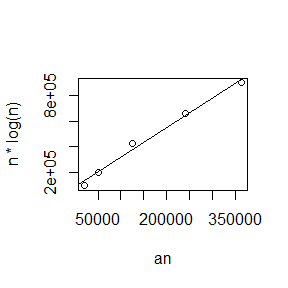

```r
plot(c,n*log(n),xlab='an')
an = c
tn = n*log(n)
modelreg = lm(tn~an)

abline(modelreg)
```

# —–Homework3-2024.09.30—–

### Question 1: Exercise 6.6 from 《Statistical Computing with R》

Estimate the 0.025, 0.05, 0.95, and 0.975 quantiles of the skewness $\sqrt{b_1}$ under normality by a Monte Carlo experiment. Compute the standard error of the estimates from (2.14) $Var(\hat{x}_q)=\frac{q(1-q)}{nf(x_q)^2}$, using the normal approximation for the density (with exact variance formula). Compare the estimated quantiles with the quantiles of the large sample approximation $\sqrt{b_1}$ ≈ $N(0, 6/n)$.

### Answer for Question 1:

```r
# 设置参数
n <- 1000  # 样本大小
m <- 10000  # Monte Carlo模拟次数
quantile_probs <- c(0.025, 0.05, 0.95, 0.975)

# 定义偏度函数，避免负数的平方根
calc_skewness <- function(x) {
  mean_x <- mean(x)
  sd_x <- sd(x)
  n <- length(x)
  skewness <- sum((x - mean_x)^3) / (n * sd_x^3)
  if (skewness >= 0) {
    return(sqrt(skewness))  # 取平方根
  } else {
    return(NA)  # 返回NA避免负值
  }
}

# Monte Carlo模拟
set.seed(123)
skew_vals <- numeric(m)
for (i in 1:m) {
  sample_data <- rnorm(n)
  skew_vals[i] <- calc_skewness(sample_data)
}

# 去除产生NA的情况
skew_vals <- skew_vals[!is.na(skew_vals)]

# 估计分位数
estimated_quantiles <- quantile(skew_vals, probs = quantile_probs)

# 计算标准误差，根据公式(2.14)
calc_standard_error <- function(q, n, f_xq) {
  sqrt(q * (1 - q) / (n * f_xq^2))
}

# 获取分位数处的密度值
f_xq_vals <- dnorm(qnorm(quantile_probs))

# 标准误差
se_vals <- mapply(calc_standard_error, quantile_probs, MoreArgs = list(n = n, f_xq = f_xq_vals))

# 计算大样本近似的分位数
large_sample_quantiles <- qnorm(quantile_probs, mean = 0, sd = sqrt(6 / n))

# 输出结果
cat("Monte Carlo估计的分位数:\n", estimated_quantiles, "\n")
```

```
## Monte Carlo估计的分位数:
##  0.05019391 0.06921798 0.3872401 0.4168929
```

```r
cat("标准误差:\n", se_vals, "\n")
```

```
## 标准误差:
##  0.08447427 0.04787001 0.04787001 0.08447427 0.1179231 0.06682486 0.06682486 0.1179231 0.1179231 0.06682486 0.06682486 0.1179231 0.08447427 0.04787001 0.04787001 0.08447427
```

```r
cat("大样本近似分位数:\n", large_sample_quantiles, "\n")
```

```
## 大样本近似分位数:
##  -0.1518182 -0.1274098 0.1274098 0.1518182
```

### Question 2: Exercise 6.B from 《Statistical Computing with R》

Tests for association based on Pearson product moment correlation $ρ$, Spear-man’s rank correlation coefficient $ρ_s$, or Kendall’s coefficient $τ$, are implemented in cor.test. Show (empirically) that the nonparametric tests based on $ρ_s$ or $τ$ are less powerful than the correlation test when the sampled distribution is bivariate normal. Find an example of an alternative (a bivariate distribution $(X, Y )$ such that $X$ and $Y$ are dependent) such that at least one of the nonparametric tests have better empirical power than the correlation test against this alternative.

### Answer for Question 2:

```r
asstest <- function(seed){
seed <- set.seed(123)
x <- rnorm(20,2,10)
sigma <- rnorm(20,5,50)  #生成正态分布的随机数
y <- 3*x+sigma
cor(x,y)
pearson <- cor.test(x,y) #变量相关性显著性检验
kendall <- cor.test(x,y,method = 'kendall')
spearman <- cor.test(x,y,method = 'spearman')
data.frame(x,y)
return(list(pearson=pearson,kendall=kendall,spearman=spearman))
}
asstest()
```

```
## $pearson
##
##  Pearson's product-moment correlation
##
## data:  x and y
## t = 2.6052, df = 18, p-value = 0.0179
## alternative hypothesis: true correlation is not equal to 0
## 95 percent confidence interval:
##  0.1050841 0.7842035
## sample estimates:
##       cor
## 0.5232718
##
##
## $kendall
##
##  Kendall's rank correlation tau
##
## data:  x and y
## T = 136, p-value = 0.007346
## alternative hypothesis: true tau is not equal to 0
## sample estimates:
##       tau
## 0.4315789
##
##
## $spearman
##
##  Spearman's rank correlation rho
##
## data:  x and y
## S = 532, p-value = 0.00608
## alternative hypothesis: true rho is not equal to 0
## sample estimates:
## rho
## 0.6
```

### Question 3:

If we obtain the powers for two methods under a particular simulation setting with 10,000 experiments: say, 0.651 for one method and 0.676 for another method. We want to know if the powers are different at 0.05 level.

(1). What is the corresponding hypothesis test problem?

(2). What test should we use? Z-test, two-sample t-test, paired-t test or McNemar test? Why?

(3). Please provide the least necessary information for hypothesis testing.

### Answr for Question 3:

(1). Using Z-test and paired t-test as examples, the corresponding hypothesis test problem: $H_0$:The powers of the Z-test and paired-t test are the same$(p_1=p_2)$ $H_1$:The powers of the Z-test and paired-t test are different$(p_1\neq{}p_2)$.

(2). The three tests are suitable, except two-sample t-test. Because the statistic of two-sample t-test is $T=\frac{p_1-p_2}{s_p\sqrt{\frac{1}{n_1}+\frac{1}{n_2}}}$, where $s_p = \sqrt{\frac{(n_1-1)s_1^2+(n_2-1)s_2^2}{n_1+n_2-2}}$,$s_1^2$ and $s_2^2$ are sample variances, it is not significant when $n_1=n_2$.

(3). Here, $p_1$is the power of the Z-test (0.651), and $p_2$is the power of the paired-t test (0.676). The sample size for each test is 10,000 (10,000 experiments).

The test statistic for comparing two proportions is: $z = \frac{p_1-p_2}{\sqrt{\hat{p}(1-\hat{p})(\frac{1}{n_1}+\frac{1}{n_2})}}$,where $\hat{p}=\frac{p_1n_1+p_2n_2}{n_1+n_2}, n_1=n_2=10000$.

```r
# Given powers for the two tests
p1 <- 0.651  # Power for Z-test
p2 <- 0.676  # Power for paired-t test
n1 <- 10000  # Number of experiments for Z-test
n2 <- 10000  # Number of experiments for paired-t test

# Pooled proportion
p_hat <- (p1 * n1 + p2 * n2) / (n1 + n2)

# Standard error
se <- sqrt(p_hat * (1 - p_hat) * (1/n1 + 1/n2))

# Test statistic (z-score)
z <- (p1 - p2) / se

# Two-tailed p-value
p_value <- 2 * pnorm(-abs(z))

# Output the z-score and p-value
cat("Z-score:", z, "\n")
```

```
## Z-score: -3.741209
```

```r
cat("P-value:", p_value, "\n")
```

```
## P-value: 0.0001831369
```

```r
# Decision based on p-value at 0.05 significance level
if (p_value < 0.05) {
  cat("Reject the null hypothesis: the powers are significantly different.\n")
} else {
  cat("Fail to reject the null hypothesis: no significant difference in powers.\n")
}
```

```
## Reject the null hypothesis: the powers are significantly different.
```

# —–Homework4-2024.10.14—–

### Question 1:

Of N = 1000 hypotheses, 950 are null and 50 are alternative. The p-value under any null hypothesis is uniformly distributed (use runif), and the p-value under any alternative hypothesis follows the beta distribution with parameter 0.1 and 1 (use rbeta). Obtain Bonferroni adjusted p-values and B-H adjusted p-values. Calculate FWER, FDR, and TPR under nominal level α = 0.1 for each of the two adjustment methods based on m = 10000 simulation replicates.

### Answer for Question 1:

```r
N = 1000; N0 = 950; N1 = 50; a = 0.1; M = 1e4
temp1 = temp2 = numeric(N)
fwer_bon = fwer_bh = fdr_bon = fdr_bh = tpr_bon = tpr_bh = numeric(M) #初始化

for (m in 1:M){  # 10000次遍历

  pnull = runif(950); palt = rbeta(50,0.1,1); pall = c(pnull,palt) #生成原假设和备择假设下p值的随机数
  padj_bon = p.adjust(pall, method = 'bonferroni') #用两种方法计算调整的p值
  padj_bh = p.adjust(pall, method = 'fdr')
  fwer_bon[m] = mean(1-(1-padj_bon)**N)  # 计算两种修正p值下的fwer
  fwer_bh[m] = mean(1-(1-padj_bh)**N)

  p_bon_sort = sort(padj_bon) # 计算bonferroni方法的fdr值
  for(i in seq(N)){
    if(p_bon_sort[i] <= i*a/N){
      temp1[i] = p_bon_sort[i]
    }
  }
  fdr_bon[m] = N0*max(temp1)/which(temp1 == max(temp1))

  p_bh_sort = sort(padj_bh) # 计算B-H方法的fdr值
  for(i in seq(N)){
    if(p_bh_sort[i] <= i*a/N){
      temp2[i] = p_bh_sort[i]
    }
  }
  fdr_bh = N0*max(temp2)/which(temp2 == max(temp2))

  paltadj_bon = p.adjust(palt, method = 'bonferroni')
  paltadj_bh = p.adjust(palt, method = 'fdr')
  tpr_bon[m] = length(which(paltadj_bon<a))/N1  # 分别计算tpr
  tpr_bh[m] = length(which(paltadj_bh<a))/N1

}

t = rbind(
  FWER = c(mean(fwer_bon), mean(fwer_bh)),  # 输出表格
  FDR = c(mean(fdr_bon),mean(fdr_bh)),
  TPR = c(mean(tpr_bon),mean(tpr_bh))
)
colnames(t) = c('Bonferroni correction','B-H correction')
knitr::kable(t,format = 'markdown')
```

|  | Bonferroni correction | B-H correction |
| --- | --- | --- |
| FWER | 0.9880906 | 0.9842470 |
| FDR | 0.0853122 | 0.0906303 |
| TPR | 0.5363600 | 0.7735360 |

### Question 2:

Refer to the air-conditioning data set aircondit provided in the boot package. The 12 observations are the times in hours between failures of airconditioning equipment [63, Example 1.1]: 3, 5, 7, 18, 43, 85, 91, 98, 100, 130, 230, 487. Assume that the times between failures follow an exponential model Exp(λ). Obtain the MLE of the hazard rate λ and use bootstrap to estimate the bias and standard error of the estimate.

### Answer for Question 2:

```r
obs = c(3, 5, 7, 18, 43, 85, 91, 98, 100, 130, 230, 487) # aircondit数据
B = 1e4; thetastar = numeric(B)
theta = mean(obs)  # 样本均值

for(b in 1:B){
  obsstar = sample(obs, replace = TRUE) # 每一次抽样，共抽10000次
  thetastar[b] = mean(obsstar)   # 计算抽取的样本均值
}

round(c(
  mle = 1/mean(obs), bias = mean(thetastar)-theta, se.boot = sd(thetastar), se.samp = sd(obs)/sqrt(length(obs))
),3)
```

```
##     mle    bias se.boot se.samp
##   0.009  -0.260  37.537  39.327
```

### Question 3:

Refer to Exercise 7.4. Compute 95% bootstrap confidence intervals for the mean time between failures 1/λ by the standard normal, basic, percentile, and BCa methods. Compare the intervals and explain why they may differ.

### Answer for Question 3:

```r
m<-1e3;library(boot);set.seed(12345)
obs = c(3, 5, 7, 18, 43, 85, 91, 98, 100, 130, 230, 487)  # aircondit数据
lambda = 1/mean(obs)  # 指数分布lambda的估计
boot.mean <- function(x,i) 1/mean(x[i])  # 定义均值函数
ci.norm<-ci.basic<-ci.perc<-ci.bca<-matrix(NA,m,2)
for(i in 1:m){
  R = sample(obs, replace = TRUE)  #抽取样本
  de <- boot(data=R,statistic=boot.mean, R = 999) # 自举法
  ci <- boot.ci(de,type=c("norm","basic","perc","bca"))  #自举法置信区间
  ci.norm[i,]<-ci$norm[2:3];ci.basic[i,]<-ci$basic[4:5]
  ci.perc[i,]<-ci$percent[4:5];ci.bca[i,]<-ci$bca[4:5]
}

ciinterval = round(rbind(norm = c(mean(ci.norm[,1]),mean(ci.norm[,2])),  # 输出4种方法的置信区间
                         basic = c(mean(ci.basic[,1]),mean(ci.basic[,2])),
                         perc = c(mean(ci.perc[,1]),mean(ci.perc[,2])),
                         BCa = c(mean(ci.bca[,1]), mean(ci.bca[,2]))
                         ),3)
colnames(ciinterval) = c('lowbound', 'upbound')
ciinterval
```

```
##       lowbound upbound
## norm     0.000   0.019
## basic   -0.003   0.015
## perc     0.007   0.024
## BCa      0.006   0.021
```

```r
cat('norm =',mean(ci.norm[,1]<=lambda & ci.norm[,2]>=lambda),   # 计算每种方法的正确率
    'basic =',mean(ci.basic[,1]<=lambda & ci.basic[,2]>=lambda),
    'perc =',mean(ci.perc[,1]<=lambda & ci.perc[,2]>=lambda),
    'BCa =',mean(ci.bca[,1]<=lambda & ci.bca[,2]>=lambda))
```

```
## norm = 0.942 basic = 0.861 perc = 0.799 BCa = 0.83
```

Why are they differ? Because the 4 methods are based on different calculations.

For “normal” method, it’s based on asymptotic normality distribution, which has the confidence interval: $(\hat\theta-z_{1-\alpha/2}\hat{se}(\hat\theta),\hat\theta+z_{1-\alpha/2}\hat{se}(\hat\theta))$.

For “basic” method, it’s based on large sample property, which assumes that $\hat{\theta^*}-\hat\theta|X$ and $\hat{\theta^*}-\theta$ have the same symptotic distribution, with CI:$(\hat\theta-F^{-1}(1-\alpha/2), \hat\theta-F^{-1}(\alpha/2))$.

For “percent” method, it assumes $\hat\theta^*|X$ and $\hat\theta$ have the same distribution, with CI: $(\hat\theta^*_{\alpha/2}, \hat\theta^*_{1-\alpha/2})$.

For “BCa” method, CI = $(\hat\theta^*_{\alpha1}, \hat\theta^*_{\alpha2})$.

# —–Homework5-2024.21—–

### Question 1: exercise 7.8 from

Refer to Exercise 7.7. Obtain the jackknife estimates of bias and standard error of $\hat\theta$

### Answer for question 1:

```r
library(MASS); library(bootstrap); data(scor)
# 定义生成函数
datagene = function(data){
  cov_matrix = cov(data)
  eigenvalues = eigen(cov_matrix)$values
  theta = eigenvalues[1]/sum(eigenvalues)
  return(theta)
}


# 定义推断函数
statisinference = function(data){
  n = nrow(data) # scor数据的样本量
  theta_jack = numeric(n)
  for(i in 1:n){
    scor_jack = data[-i,]   # 将scor数据去除第i个观测值
    theta_jack[i] = datagene(scor_jack) # 计算新的theta
  }
  return(theta_jack)
}


# 定义结果函数，输出偏差和标准差
resultout = function(data){
  n = nrow(data)
  # 计算偏差估计
  bias = (n-1)*(mean(statisinference(data))-datagene(data))
  # 计算标准差估计
  se = sqrt((n-1)/n*sum((statisinference(data)-mean(statisinference(data)))^2))
  round(c(bias = bias, se = se),5)
}

# 调用结果函数
resultout(scor)
```

```
##    bias      se
## 0.00107 0.04955
```

### Question 2: exercise 7.10 from

In Example 7.18, leave-one-out (n-fold) cross validation was used to select the best fitting model. Repeat the analysis replacing the Log-Log model with a cubic polynomial model. Which of the four models is selected by the cross validation procedure? Which model is selected according to maximum adjusted $R^2$?

### Answer for question 2:

```r
library(DAAG, quietly = TRUE); data(ironslag)
## 定义生成函数
datagene2 = function(){
  magnetic = ironslag$magnetic

  n = length(magnetic)
  return(n)
}

## 定义推断函数
modelreg = function(){
  n = datagene2(); magnetic = ironslag$magnetic; chemical = ironslag$chemical
  e1 = numeric(n)
  for(k in 1:n){
    y = magnetic[-k] # 交叉验证，剔除第k个值
    x = chemical[-k]

    # 四个模型拟合
    J1 = lm(y ~ x)
    yhat1 = J1$coef[1] + J1$coef[2] * chemical[k]
    e1[k] = magnetic[k] -yhat1

    round(c(linear_bias = mean(e1^2)),4)

    return(summary(J1))
  }
}

## 定义输出函数
result2out = function(){
  n = datagene2(); magnetic = ironslag$magnetic; chemical = ironslag$chemical; e2 = numeric(n)
  for(k in 1:n){
    y = magnetic[-k] # 交叉验证，剔除第k个值
    x = chemical[-k]

    J2 = lm(y ~ x + I(x^2))
    yhat2 = J2$coef[1] + J2$coef[2] * chemical[k] + J2$coef[3] * chemical[k]^2
    e2[k] = magnetic[k] - yhat2
  }
  round(c(quadratic = mean(e2^2)), 4)
  return(summary(J2))
}

result3out = function(){
  n = datagene2(); magnetic = ironslag$magnetic; chemical = ironslag$chemical; e3 = numeric(n)
  for(k in 1:n){
    y = magnetic[-k] # 交叉验证，剔除第k个值
    x = chemical[-k]

    J3 = lm(log(y) ~ x)
    yhat3 = J3$coef[1] + J3$coef[2] * chemical[k]
    e3[k] = magnetic[k] - yhat3
  }
  round(c(expo = mean(e3^2)), 4)
  return(summary(J3))
}

result4out = function(){
  n = datagene2(); magnetic = ironslag$magnetic; chemical = ironslag$chemical; e4 = numeric(n)
  for(k in 1:n){
    y = magnetic[-k] # 交叉验证，剔除第k个值
    x = chemical[-k]

    J4 = lm(y ~ x + I(x^2) + I(x^3))
    yhat4 = J4$coef[1] +J4$coef[2]*chemical[k] + J4$coef[3]*chemical[k]^2 + J4$coef[4]*chemical[k]^3
    e4[k] = magnetic[k] - yhat4
  }
  round(c(cubic = mean(e4^2)),4)
  return(summary(J4))
  #return(mean(e4^2))
}

## 调用输出函数
modelreg()
```

```
##
## Call:
## lm(formula = y ~ x)
##
## Residuals:
##    Min     1Q Median     3Q    Max
## -9.691 -2.471 -0.059  2.108 11.748
##
## Coefficients:
##             Estimate Std. Error t value Pr(>|t|)
## (Intercept)   1.4474     2.6091   0.555    0.582
## x             0.9122     0.1204   7.575 7.59e-10 ***
## ---
## Signif. codes:  0 '***' 0.001 '**' 0.01 '*' 0.05 '.' 0.1 ' ' 1
##
## Residual standard error: 4.364 on 50 degrees of freedom
## Multiple R-squared:  0.5344, Adjusted R-squared:  0.5251
## F-statistic: 57.39 on 1 and 50 DF,  p-value: 7.585e-10
```

```r
result2out()
```

```
##
## Call:
## lm(formula = y ~ x + I(x^2))
##
## Residuals:
##     Min      1Q  Median      3Q     Max
## -8.2243 -2.4454 -0.1374  2.2346 12.5821
##
## Coefficients:
##             Estimate Std. Error t value Pr(>|t|)
## (Intercept) 25.98525    8.75932   2.967  0.00464 **
## x           -1.52948    0.85065  -1.798  0.07834 .
## I(x^2)       0.05707    0.01991   2.867  0.00609 **
## ---
## Signif. codes:  0 '***' 0.001 '**' 0.01 '*' 0.05 '.' 0.1 ' ' 1
##
## Residual standard error: 3.915 on 49 degrees of freedom
## Multiple R-squared:  0.607,  Adjusted R-squared:  0.591
## F-statistic: 37.84 on 2 and 49 DF,  p-value: 1.154e-10
```

```r
result3out()
```

```
##
## Call:
## lm(formula = log(y) ~ x)
##
## Residuals:
##      Min       1Q   Median       3Q      Max
## -0.63621 -0.08603 -0.00391  0.10665  0.44188
##
## Coefficients:
##             Estimate Std. Error t value Pr(>|t|)
## (Intercept) 2.127402   0.115186  18.469  < 2e-16 ***
## x           0.040570   0.005321   7.624 6.37e-10 ***
## ---
## Signif. codes:  0 '***' 0.001 '**' 0.01 '*' 0.05 '.' 0.1 ' ' 1
##
## Residual standard error: 0.1924 on 50 degrees of freedom
## Multiple R-squared:  0.5376, Adjusted R-squared:  0.5283
## F-statistic: 58.13 on 1 and 50 DF,  p-value: 6.371e-10
```

```r
result4out()
```

```
##
## Call:
## lm(formula = y ~ x + I(x^2) + I(x^3))
##
## Residuals:
##     Min      1Q  Median      3Q     Max
## -8.4347 -2.0627 -0.3247  2.2127 13.1177
##
## Coefficients:
##              Estimate Std. Error t value Pr(>|t|)
## (Intercept) -2.763718  26.402670  -0.105    0.917
## x            2.908468   3.938834   0.738    0.464
## I(x^2)      -0.160916   0.189976  -0.847    0.401
## I(x^3)       0.003424   0.002968   1.154    0.254
##
## Residual standard error: 3.902 on 48 degrees of freedom
## Multiple R-squared:  0.6176, Adjusted R-squared:  0.5937
## F-statistic: 25.84 on 3 and 48 DF,  p-value: 4.264e-10
```

According to the maximun $R^2$ among the four models, cubic polinomial model should be chosen with adjust R square = 59.4%.

### Question 3: exercise 8.1 from

Implement the two-sample Cram´er-von Mises test for equal distributions as a permutation test. Apply the test to the data in Examples 8.1 and 8.2.

### Answer for question 3:

```r
## 定义生成函数
rep = 1000
genexs = function(){
  feed = chickwts$feed
  feed1 = "soybean"
  attach(chickwts)
  xs = sort(as.vector(weight[feed == "soybean"])) # 生成soybean的重排
  detach(chickwts)
  return(xs)
}

geneys = function(){
  feed = chickwts$feed
  attach(chickwts)
  ys = sort(as.vector(weight[feed == 'linseed'])) # 生成linseed的重排
  detach(chickwts)
  return(ys)
}


## 定义推断函数
permu_pro = function(){
  library(cramer)
  xs = genexs()
  ys = geneys()
  zs = c(xs, ys)
  n1 = length(xs)
  n2 = length(ys)
  n = n1 + n2

  Ts = numeric(rep)
  for (i in 1:rep) {
    ks = sample(1:n, n1, replace = FALSE)
    zs1 = zs[ks]
    zs2 = zs[-ks]
    Ts[i] = cramer.test(zs1, zs2)$statistic
  }

  cra = cramer.test(xs, ys)
  T.hat = cra$statistic
  round(c(p.hat = mean(abs(T.hat) < abs(c(T.hat, Ts)))),4)


}

permu_sum = function(){
  library(cramer)
  xs = genexs()
  ys = geneys()
  zs = c(xs, ys)
  n1 = length(xs)
  n2 = length(ys)
  n = n1 + n2

  Ts = numeric(rep)
  for (i in 1:rep) {
    ks = sample(1:n, n1, replace = FALSE)
    zs1 = zs[ks]
    zs2 = zs[-ks]
    Ts[i] = cramer.test(zs1, zs2)$statistic
  }

  cra = cramer.test(xs, ys)
  T.hat = cra$statistic
  #round(c(p.hat = mean(abs(T.hat) < abs(c(T.hat, Ts)))),4)
  return(cra)
  #hist(Ts)

}

permu_hist = function(){
  library(cramer)
  xs = genexs()
  ys = geneys()
  zs = c(xs, ys)
  n1 = length(xs)
  n2 = length(ys)
  n = n1 + n2

  Ts = numeric(rep)
  for (i in 1:rep) {
    ks = sample(1:n, n1, replace = FALSE)
    zs1 = zs[ks]
    zs2 = zs[-ks]
    Ts[i] = cramer.test(zs1, zs2)$statistic
  }

  cra = cramer.test(xs, ys)
  T.hat = cra$statistic

  hist(Ts)

}


# 调用函数
permu_pro()
```

```
##  p.hat
## 0.3676
```

```r
permu_sum()
```

```
##
##  1 -dimensional  nonparametric Cramer-Test with kernel phiCramer
## (on equality of two distributions)
##
##  x-sample:  14  values        y-sample:  12  values
##
## critical value for confidence level  95 % :  79.63004
## observed statistic  29.85073 , so that
##   hypothesis ("x is distributed as y") is  ACCEPTED .
## estimated p-value =  0.3816184
##
##  [result based on  1000   ordinary  bootstrap-replicates]
```

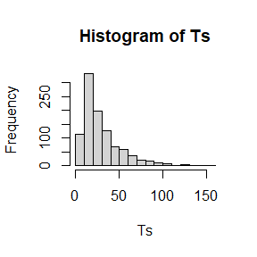

```r
permu_hist()
```

### Question 4:exercise 8.2 from

Implement the bivariate Spearman rank correlation test for independence [255] as a permutation test. The Spearman rank correlation test statistic can be obtained from function cor with method = “spearman”. Compare the achieved significance level of the permutation test with the p-value reported by cor.test on the same samples

### Answer for question 4:

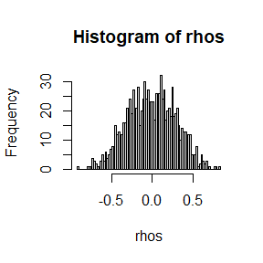

```
##
##  Spearman's rank correlation rho
##
## data:  soybean and linseed
## S = 0, p-value < 2.2e-16
## alternative hypothesis: true rho is not equal to 0
## sample estimates:
## rho
##   1
```

```r
## 定义生成函数
data(chickwts)
datagene4= function(){
  attach(chickwts)
  soybean = chickwts$weight[chickwts$feed=="soybean"]
  linseed = chickwts$weight[chickwts$feed=="linseed"]
  detach(chickwts)
  n = length(soybean)
  m = length(linseed)

  tmp = min(n, m)
  soybean = sort(soybean[1:tmp])
  linseed = sort(linseed[1:tmp])

  return(list(soybean = soybean, linseed = linseed))
}

## 定义推断函数
spearman_fun = function(B){
  soybean = datagene4()$soybean
  linseed = datagene4()$linseed
  zs = c(soybean, linseed)
  spearman_cortest = cor.test(x = soybean, y = linseed, method = "spearman")

  k = length(zs)

  rhos = numeric(B)

  for (b in 1:B) {
    i = sample(1:k, k/2, replace = FALSE)
    xs = zs[i]
    ys = zs[-i]
    rhos[b] = cor(x = xs, y = ys, method = "spearman")
  }

  hist(rhos, breaks = 100)
  theta.hat = spearman_cortest$estimate
  p.hat = mean(abs(rhos) > abs(theta.hat))
  return(spearman_cortest)
}

spearman_fun2 = function(B){
  soybean = datagene4()$soybean
  linseed = datagene4()$linseed
  zs = c(soybean, linseed)
  spearman_cortest = cor.test(x = soybean, y = linseed, method = "spearman")

  k = length(zs)

  rhos = numeric(B)

  for (b in 1:B) {
    i = sample(1:k, k/2, replace = FALSE)
    xs = zs[i]
    ys = zs[-i]
    rhos[b] = cor(x = xs, y = ys, method = "spearman")
  }

  theta.hat = spearman_cortest$estimate
  p.hat = mean(abs(rhos) > abs(theta.hat))
  return(p.hat)
  }

## 调用推断函数，画直方图
spearman_fun(1000)
```

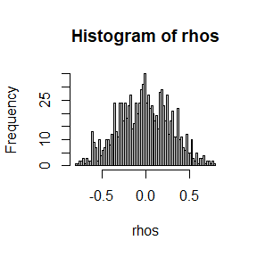

```
## theta.hat.rho       p.value
##             1             0
```

```r
## 定义结果函数
resultout4 = function(){
  spearman_cortest = spearman_fun(1000)
  theta.hat = spearman_cortest$estimate
  p.value = spearman_cortest$p.value


  round(c( theta.hat = theta.hat, p.value = p.value),3)
}

resultout4() # 调用函数
```

```r
spearman_fun2(1000) # 输出p.hat
```

```
## [1] 0
```

# —–Homework6-2024.10.28—–

### Question 1:

Use the Metropolis-Hastings sampler to generate random variables from a standard Cauchy distribution. Discard the first 1000 of the chain, and compare the deciles of the generated observations with the deciles of the standard Cauchy distribution (see qcauchy or qt with df=1). Recall that a Cauchy(θ, η) distribution has density function:$f(x)=\frac{1}{\theta\pi(1+[(x-\eta)/\theta]^2)},-\infty<x<\infty, \theta>0$ The standard Cauchy has the Cauchy(θ = 1, η = 0) density. (Note that the standard Cauchy density is equal to the Student t density with one degree of freedom.)

### Answer for Question 1:

```
## p.reject
##   0.2234
```

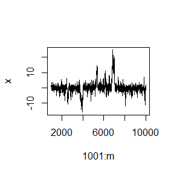

```
## p.reject
##   0.2066
```

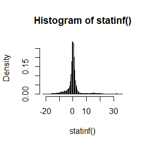

```
## deciles of generation observation.10%           deciles of standard qcauchy
##                               -2.9370                               -3.0777
```

```r
## 定义生成函数：柯西分布
 f <- function(x) {

        return(1/(pi*(1+x^2)))
    }

# 定义统计推断函数：
statinf = function(){
    m <- 10000
    x <- numeric(m)
    x[1] <- rnorm(1, mean=1)
    k <- 0
    u <- runif(m)

    for (i in 2:m) {
        xt <- x[i-1]
        y <- rnorm(1, mean = xt)
        num <- f(y) * dnorm(xt, mean = y)
        den <- f(xt) * dnorm(y, mean = xt)
        if (u[i] <= num/den){
          x[i] <- y
        } else {
          x[i] <- xt
          k <- k+1     #y is rejected
        }
    }
    print(round(c('p.reject' = k/m),4))
    return(x)
}

# 定义结果输出函数
out = function(){
    m = 1e4
    b <- 1001      #discard the burn-in sample
    y <- statinf()[b:m]
    plot(1001:m, y, type = 'l', main='', ylab='x')
    # a <- ppoints(100)
    # Q <- quantile(x, a)
    hist(statinf(),probability = TRUE, breaks = 100)

    round(c('deciles of generation observation'=quantile(y,0.1),
            'deciles of standard qcauchy'=qcauchy(0.1)),4)
}

out()
```

### Question 2:

For question 1, use the Gelman-Rubin method to monitor convergence of the chain, and run the chain until it converges approximately to the target distribution according to $\hat{R}<1.2$.

### Answer for Question 2:

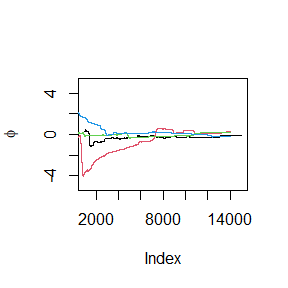

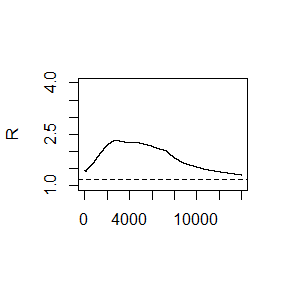

```r
# 定义生成函数，生成标准柯西分布的马尔科夫链

    cauchy.chain <- function(sigma, N, X1) {
        #generates a Metropolis chain for Cauchy(0,1)
        #with Normal(X[t], sigma) proposal distribution
        #and starting value X1
        x <- rep(0, N)
        x[1] <- X1
        u <- runif(N)

        for (i in 2:N) {
            xt <- x[i-1]
            y <- rnorm(1, xt, sigma)     #candidate point
            r1 <- dcauchy(y, 0, 1) * dnorm(xt, y, sigma)
            r2 <- dcauchy(xt, 0, 1) * dnorm(y, xt, sigma)
            r <- r1 / r2
            if (u[i] <= r) x[i] <- y else
                 x[i] <- xt
            }
        return(x)
    }


## 定义推断函数，即计算G_R的统计量
Gelman.Rubin <- function(psi) {
        # psi[i,j] is the statistic psi(X[i,1:j])
        # for chain in i-th row of X
        psi <- as.matrix(psi)
        n <- ncol(psi)
        k <- nrow(psi)

        psi.means <- rowMeans(psi)     #row means
        B <- n * var(psi.means)        #between variance est.
        psi.w <- apply(psi, 1, "var")  #within variances
        W <- mean(psi.w)               #within est.
        v.hat <- W*(n-1)/n + (B/n)     #upper variance est.
        r.hat <- v.hat / W             #G-R statistic
        return(r.hat)
        }

## 定义结果输出函数，输出四条链轨迹图及R-hat统计量序列
out2 = function(){

    sigma <- 2     #parameter of proposal distribution
    k <- 4          #number of chains to generate
    n <- 15000      #length of chains
    b <- 1000       #burn-in length

    #choose overdispersed initial values
    x0 <- c(-10,-5,5,10)

    #generate the chains
    set.seed(12345)
    X <- matrix(0, nrow=k, ncol=n)
    for (i in 1:k)
        X[i, ] <- cauchy.chain(sigma, n, x0[i])


    #compute diagnostic statistics
    psi <- t(apply(X, 1, cumsum))
    for (i in 1:nrow(psi))
        psi[i,] <- psi[i,] / (1:ncol(psi))

    #plot psi for the four chains

    for (i in 1:k)
      if(i==1){
        plot((b+1):n,psi[i, (b+1):n],ylim=c(-5,5), type="l",
            xlab='Index', ylab=bquote(phi))
      }else{
        lines(psi[i, (b+1):n], col=i)
    }
    par(mfrow=c(1,1)) #restore default

    #plot the sequence of R-hat statistics
    rhat <- rep(0, n)
    for (j in (b+1):n){
      rhat[j] <- Gelman.Rubin(psi[,1:j])
    }

    plot(rhat[(b+1):n], type="l", xlab="", ylab="R", ylim = c(1,4))
    abline(h=1.2, lty=2)
}
out2()
```

### Answer for Question 3:

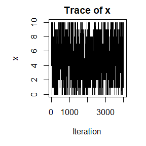

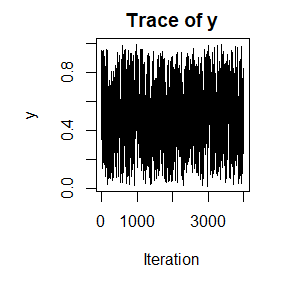

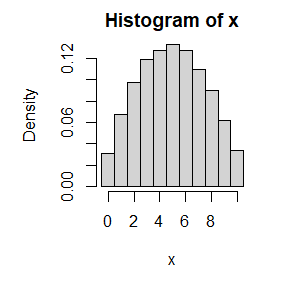

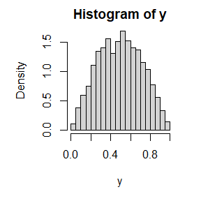

```r
# 设置参数
n <- 10      # 样本大小
a <- 2       # Beta分布的参数
b <- 2       # Beta分布的参数
N <- 5000  # Gibbs采样的迭代次数
burn = 1000

# 1. 生成Gibbs采样的数据
generate_samples <- function(n, a, b, iterations) {
  x_samples <- numeric(iterations)
  y_samples <- numeric(iterations)
  y <- 0.5  # 初始化 y 的初始值

  for (i in 1:iterations) {
    x <- rbinom(1, n, y)              # 从 x | y 的条件分布采样
    y <- rbeta(1, x + a, n - x + b)   # 从 y | x 的条件分布采样

    x_samples[i] <- x
    y_samples[i] <- y

    xx_samples = x_samples[(burn+1):N] # 取1001-5000样本
    yy_samples = y_samples[(burn+1):N]
  }

  return(list(xx_samples = xx_samples, yy_samples = yy_samples))
}

# 2. 进行统计推断
statistical_analysis <- function(samples) {
  xx = samples$xx_samples
  yy = samples$yy_samples
  x_mean <- mean(xx)
  y_mean <- mean(yy)
  x_var <- var(xx)
  y_var <- var(yy)

  return(list(x_mean = x_mean, y_mean = y_mean, x_var = x_var, y_var = y_var))
}

# 3. 输出结果，包括轨迹图和直方图
plot_results <- function(samples) {
  par(mar = c(5, 5, 2, 2))

  # x 和 y 的轨迹图
  plot(samples$xx_samples, type = "l", main = "Trace of x", xlab = "Iteration", ylab = "x")
  plot(samples$yy_samples, type = "l", main = "Trace of y", xlab = "Iteration", ylab = "y")

  # x 和 y 的直方图
  hist(samples$xx_samples, breaks = seq(-0.5, n + 0.5, by = 1), main = "Histogram of x", xlab = "x", probability = TRUE)
  hist(samples$yy_samples, breaks = 30, main = "Histogram of y", xlab = "y", probability = TRUE)
}

# 主程序
samples <- generate_samples(n, a, b, N)        # 生成样本
analysis_results <- statistical_analysis(samples)        # 统计推断
plot_results(samples)                                    # 输出结果
```

```r
# 打印统计推断的结果
print(analysis_results)
```

```
## $x_mean
## [1] 4.9505
##
## $y_mean
## [1] 0.4962101
##
## $x_var
## [1] 6.56169
##
## $y_var
## [1] 0.04697326
```

### Question 4

For question 3, use the Gelman-Rubin method to monitor convergence of the chain, and run the chain until it converges approximately to the target distribution according to $\hat{R}<1.2$.

### Answer for QUestion 4:

```r
# 加载coda包
if (!require(coda)) install.packages("coda")
library(coda)

# 设置参数
n <- 10
a <- 2
b <- 2
iterations <- 10000  # 每条链的最大迭代次数
chains <- 4          # 使用的链数量

# 1. 生成多条独立的Gibbs采样链
generate_samples <- function(n, a, b, iterations) {
  x_samples <- numeric(iterations)
  y_samples <- numeric(iterations)
  y <- 0.5  # 初始化 y 的初始值

  for (i in 1:iterations) {
    x <- rbinom(1, n, y)              # 从 x | y 的条件分布采样
    y <- rbeta(1, x + a, n - x + b)   # 从 y | x 的条件分布采样

    x_samples[i] <- x
    y_samples[i] <- y
  }

  return(list(x_samples = x_samples, y_samples = y_samples))
}

# 生成多条链
chains_x <- lapply(1:chains, function(i) generate_samples(n, a, b, iterations)$x_samples)
chains_y <- lapply(1:chains, function(i) generate_samples(n, a, b, iterations)$y_samples)

# 将链转换为mcmc.list对象
mcmc_chains_x <- mcmc.list(lapply(chains_x, mcmc))
mcmc_chains_y <- mcmc.list(lapply(chains_y, mcmc))

# 2. 使用Gelman-Rubin方法监测收敛性
check_convergence <- function(mcmc_chains, variable_name) {
  gelman_diag <- gelman.diag(mcmc_chains, autoburnin = FALSE)
  cat(paste("Gelman-Rubin statistic for", variable_name, ":", gelman_diag$psrf[1,1], "\n"))
  return(gelman_diag$psrf[1,1] < 1.2)  # 返回是否收敛
}

# 3. 检查链的收敛性
converged_x <- check_convergence(mcmc_chains_x, "x")
```

```
## Gelman-Rubin statistic for x : 1.00010512272904
```

```r
converged_y <- check_convergence(mcmc_chains_y, "y")
```

```
## Gelman-Rubin statistic for y : 1.00015071926496
```

```r
# 输出收敛结果
if (converged_x && converged_y) {
  cat("Both chains have converged (Gelman-Rubin < 1.2)\n")
} else {
  cat("Chains have not yet converged. Consider running more iterations.\n")
}
```

```
## Both chains have converged (Gelman-Rubin < 1.2)
```

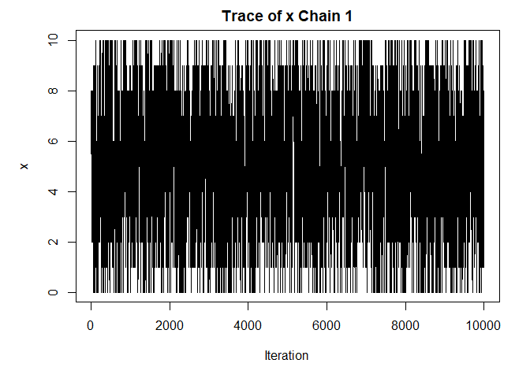

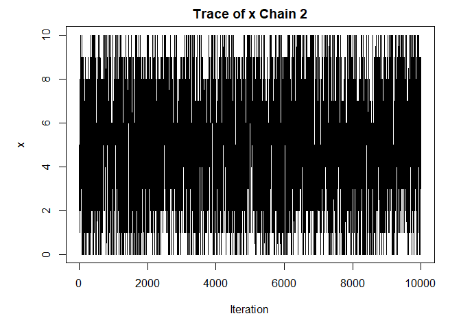

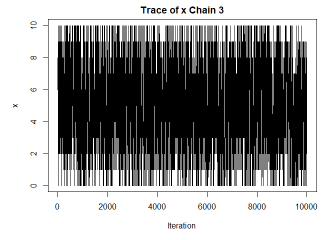

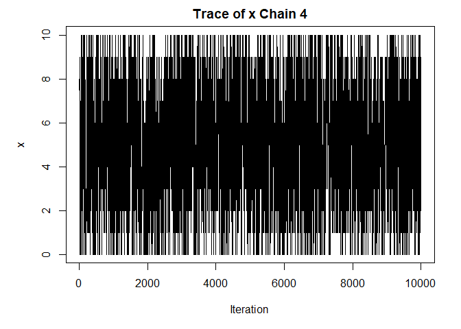

```r
# 4. 绘制链的轨迹图
plot_trace <- function(chains, variable_name) {
  par(mar = c(5, 5, 2, 2))  # 设置为2x2图形布局
  for (i in 1:length(chains)) {
    plot(chains[[i]], type = "l", main = paste("Trace of", variable_name, "Chain", i),
         xlab = "Iteration", ylab = variable_name)
  }
  par(mfrow = c(1, 1))  # 重置图形布局
}

# 绘制 x 和 y 的轨迹图
plot_trace(chains_x, "x")
```

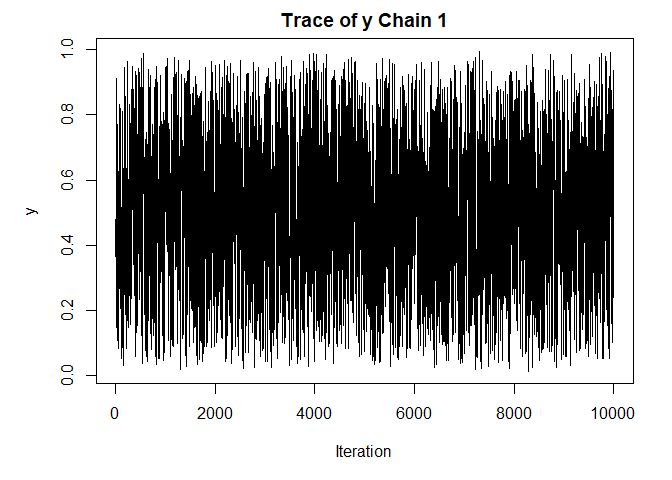

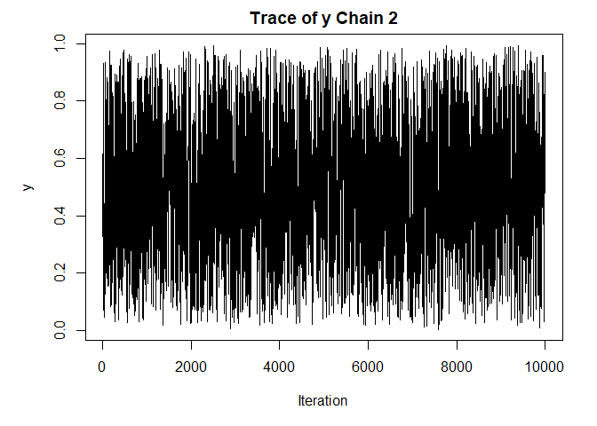

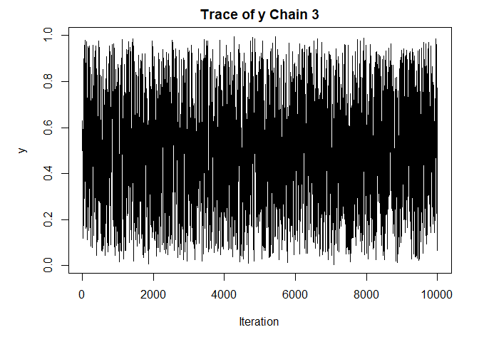

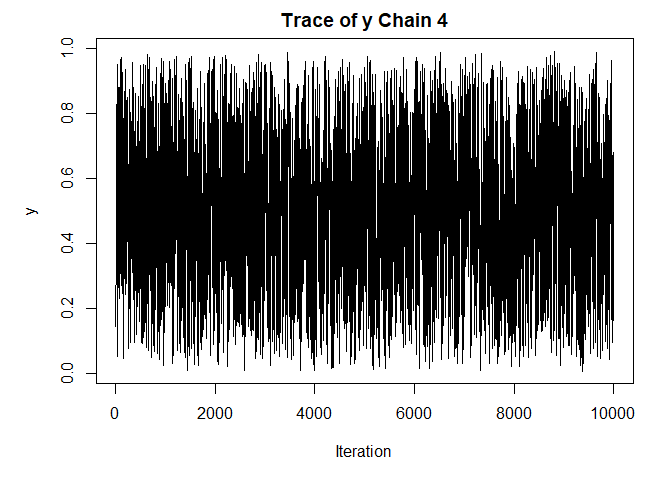

```r
plot_trace(chains_y, "y")
```

### Question 5: Proof of stationary of Metropolis-Hastings sampler Algorithm in continuous situation.

### Answer for question 5:

Please see notes in the .jpg file in this document file.

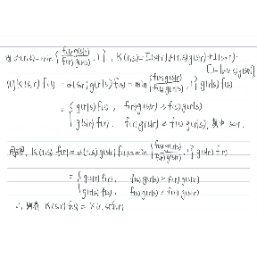

# —–Homework7-2024.11.04—–

### Question 1: exercise 11.3 from 《Statistical Computing with R》

1. Write a function to compute the $k^{th}$ term in $\sum_{k=0}^{\infty}\frac{(-1)^k}{k!2^k}\frac{||a||^{2k+1}}{(2k+1)(2k+2)}\frac{\Gamma(d/2+1)\Gamma(k+3/2)}{\Gamma(k+d/2+1)}$ where $d ≥ 1$ is an integer, a is a vector in $R^d$, and $||·||$ denotes the Euclidean norm. Perform the arithmetic so that the coefficients can be computed for (almost) arbitrarily large $k$ and $d$. (This sum converges for all $a ∈ R^d$).
2. Modify the function so that it computes and returns the sum.
3. Evaluate the sum when $a = (1,2)^T$ .

### Answer for Question 1:

For question (a), the $k^{th}$ term is:

```r
g = function(a,k){  # 计算每一项
  d = length(a)
  gg = (-1)^k * exp((2*k+2)*log(norm(a, type = '2')) + lgamma((d+1)/2) + lgamma(k+1.5) - lgamma(k+1) - k*log(2) - log(2*k+1) - log(2*k+2) - lgamma(k+d/2+1))
  return(gg)
}
```

For question (b), the sum of $k=0:\infty$ is:

```r
gsum = function(n){  # k从0到n项求和
  sg = 0
  for(i in 0:n) sg = sg + g(a,i)
  return(sg)
}
```

For question (c), the sum when $a = (1,2)^T$ is:

```r
N=1e3
a = matrix(c(1,2))
gsum(N)
```

```
## [1] 1.532164
```

### Question 2:exercise 11.5 from 《Statistical Computing with R》

Write a function to solve the equation $\frac{2\Gamma(\frac{k}{2})}{\sqrt{\pi(k-1)}\Gamma(\frac{k-1}{2})}\int_{0}^{c_{k-1}}(1+\frac{u^2}{k-1})^{-k/2}du = \frac{2\Gamma(\frac{k+1}{2})}{\sqrt{\pi k}\Gamma(\frac{k}{2})}\int_{0}^{c_{k}}(1+\frac{u^2}{k})^{-(k+1)/2}du$

for a, where $c_k = \sqrt{\frac{a^2k}{k+1-a^2}}$.

Compare the solutions with the points $A(k)$ in Exercise 11.4.

### Answer for Question 2:

To solve the equation:

```r
## 定义若干生成函数
integral = function(u, k){ #积分函数
  (1+u^2/(k-1))^(-k/2)
}

getc = function(a,k){ # 计算a

  sqrt(a^2*k/(k+1-a^2))

}

## 定义表达式函数
expr = function(a,k){

  iintegral = function(u){
    integral(u,k)
  }
  c = getc(a,k-1)

  res = 2/sqrt(pi*(k-1)) * exp(lgamma(k/2) - lgamma((k-1)/2)) * integrate(iintegral,lower = 0, upper = c)$value
  return(res)
}

g = function(a){
    expr(a,k) - expr(a,k+1)
  }
## 求解方程并输出结果

resl = function(k){
  e = 0.01
 if (g(e) < 0 && g(sqrt(k) - e) > 0 || g(e) > 0 && g(sqrt(k) - e) < 0) {
    r = uniroot(g, c(e,sqrt(k)-e))$root
    } else {
      r = NA
    }
  return(r)

}

for (k in c(4:25,100,500,1000)){
  print(resl(k))
}
```

```
## [1] 1.492073
## [1] 1.533555
## [1] 1.562745
## [1] 1.584429
## [1] 1.601184
## [1] 1.614516
## [1] 1.625389
## [1] 1.634418
## [1] 1.642026
## [1] 1.648552
## [1] 1.654175
## [1] 1.659099
## [1] 1.663454
## [1] 1.667287
## [1] NA
## [1] 1.673832
## [1] 1.676605
## [1] 1.679148
## [1] 1.681468
## [1] 1.683593
## [1] 1.685546
## [1] 1.687366
## [1] NA
## [1] NA
## [1] 1.730903
```

The solutions in exercise 11.4 are as follows. Provide the comparisons of the two:

```r
## 定义生成函数
expr2 = function(a,k){
  1-pt(sqrt(a^2*k/(k+1-a^2)), df = k)
}

g2 = function(a){  # 等式函数
  expr2(a,k) - expr2(a,k-1)
}

reslt = function(k){ # 解方程
  e = 0.01
  r = uniroot(g2, interval = c(e,sqrt(k) - e))$root
  return(r)
}

 # 输出结果对比
  for(k in c(4:25,100,500,1000)){

    p = round(c('integral solution' = resl(k),'probability solution' = reslt(k)), 3)
    print(p)
}
```

```
##    integral solution probability solution
##                1.492                1.492
##    integral solution probability solution
##                1.534                1.534
##    integral solution probability solution
##                1.563                1.563
##    integral solution probability solution
##                1.584                1.584
##    integral solution probability solution
##                1.601                1.601
##    integral solution probability solution
##                1.615                1.615
##    integral solution probability solution
##                1.625                1.625
##    integral solution probability solution
##                1.634                1.634
##    integral solution probability solution
##                1.642                1.642
##    integral solution probability solution
##                1.649                1.649
##    integral solution probability solution
##                1.654                1.654
##    integral solution probability solution
##                1.659                1.659
##    integral solution probability solution
##                1.663                1.663
##    integral solution probability solution
##                1.667                1.667
##    integral solution probability solution
##                   NA                1.671
##    integral solution probability solution
##                1.674                1.674
##    integral solution probability solution
##                1.677                1.677
##    integral solution probability solution
##                1.679                1.679
##    integral solution probability solution
##                1.681                1.681
##    integral solution probability solution
##                1.684                4.786
##    integral solution probability solution
##                1.686                4.889
##    integral solution probability solution
##                1.687                4.990
##    integral solution probability solution
##                   NA                 9.99
##    integral solution probability solution
##                   NA               22.351
##    integral solution probability solution
##                1.731               31.613
```

In exercise 11.4, intersection point $A(k)$ computed by probability of t-distribution, increses fast as k grows to 23 and above. Instead, the results computed by gamma function perform better with results within a range of two.

### Question3:

Suppose $T_1, ..., T_n$ are i.i.d. samples drawn from the exponential distribution with expectation $λ$.

Those values greater than $τ$ are not observed due to right censorship, so that the observed values are $Y_i = T_iI(T_i \leq \tau) + \tau I(T_i>\tau), i = 1,...,n.$ Suppose $τ = 1$ and the observed $Y_i$ values are as follows:

0.54, 0.48, 0.33, 0.43, 1.00, 1.00, 0.91, 1.00, 0.21, 0.85

Use the E-M algorithm to estimate $λ$, compare your result with the observed data MLE (note: $Y_i$ follows a mixture distribution)

### Answer for Question 3:

- The E-M algorithm is:
- initialize $\lambda_0 = \frac{1}{E(Y^{observed})}$
- For values greater than $\tau$, replace 1s with $E(T|T>\tau)$
- Compute new $lambda1 = \frac{1}{E(Y^{adjusted})}$
- Repeat the above steps with 1000 iterations.

```r
yo = c(0.54, 0.48, 0.33, 0.43, 1.00, 1.00, 0.91, 1.00, 0.21, 0.85)
n = length(yo)

## 定义生成函数
lambda = function(){ # 原始观测数据的lambda估计
  1/mean(yo)
}

## 统计推断函数: E-M算法
em = function(tau){
  # E算法
  lambda0 = lambda()
  yad = yo
  for(i in 1:1000){ # 迭代1000次
    # 对于修改的数据，其期望E[T|T>tau] = tao + 1/lambda
    expectedgv = tau + 1/lambda0
    # 将值为1的数据改为期望值
    yad[yo == tau] = expectedgv
    # 更新lambda
    lambda0 = 1/mean(yad)
  }
  return(lambda0)
}
## 结果输出函数
reslt3 = function(){
  round(rbind(c('E-M Algorithm' = em(1), 'Observed Data MLE' = lambda())),3)
}
reslt3()
```

```
##      E-M Algorithm Observed Data MLE
## [1,]         1.037             1.481
```

# —–Homework8-2024.11.11—–

### Question 1: Exercise 11.7 from《Statistical Computing with R》

Use the simplex algorithm to solve the following problem.

Minimize $4x + 2y + 9z$ subject to

$2x + y + z ≤ 2$ $x − y + 3z ≤ 3$ $x ≥ 0, y ≥ 0, z ≥ 0$.

### Answer for Question 1:

```r
#install.packages('nloptr')
library(nloptr)
eval_f = function(x){
  return('objective'=4*x[1]+2*x[2]+9*x[3])
}
eval_g = function(x){
  return(list('constraints'=c(2*x[1]+x[2]+x[3]-2,x[1]-x[2]+3*x[3]-3),
              'jacobian'=rbind(c(2,1,1),c(1,-1,3))))
}
res2=nloptr(x0 = c(1,1,1),
            eval_f = eval_f,
            lb = c(0,0,0),
            ub = c(Inf,Inf,Inf),
            eval_g_ineq = eval_g,
             opts = list('algorithm'='NLOPT_LN_COBYLA',"xtol_rel"=1.0e-6))
res2$solution
```

```
## [1] 0.000000e+00 0.000000e+00 2.168404e-19
```

```r
res2$objective
```

```
## [1] 1.951564e-18
```

### Question 2: Exercise 3 from 《Advanced R》, page204

Use both for loops and lapply() to fit linear models to the mtcars using the formulas stored in this list:

formulas <- list( mpg ~ disp, mpg ~ I(1 / disp), mpg ~ disp + wt, mpg ~ I(1 / disp) + wt )

### Answer for Question 2:

```r
data(mtcars)

formulas <- list(
mtcars$mpg ~ mtcars$disp,
mtcars$mpg ~ I(1 / mtcars$disp),
mtcars$mpg ~ mtcars$disp + mtcars$wt,
mtcars$mpg ~ I(1 / mtcars$disp) + mtcars$wt
)


## 使用for循环

loop_res = list()
for(i in 1:4){
  loop_res[[i]] = lm(formulas[[i]])

}
cat("循环输出结果为：",'\n')
```

```
## 循环输出结果为：
```

```r
print(loop_res)
```

```
## [[1]]
##
## Call:
## lm(formula = formulas[[i]])
##
## Coefficients:
## (Intercept)  mtcars$disp
##    29.59985     -0.04122
##
##
## [[2]]
##
## Call:
## lm(formula = formulas[[i]])
##
## Coefficients:
##      (Intercept)  I(1/mtcars$disp)
##            10.75           1557.67
##
##
## [[3]]
##
## Call:
## lm(formula = formulas[[i]])
##
## Coefficients:
## (Intercept)  mtcars$disp    mtcars$wt
##    34.96055     -0.01772     -3.35083
##
##
## [[4]]
##
## Call:
## lm(formula = formulas[[i]])
##
## Coefficients:
##      (Intercept)  I(1/mtcars$disp)         mtcars$wt
##           19.024          1142.560            -1.798
```

```r
## 使用lapply函数
cat("lapply函数输出结果为：",'\n')
```

```
## lapply函数输出结果为：
```

```r
lapply(formulas, function(f) lm(f, data = mtcars))
```

```
## [[1]]
##
## Call:
## lm(formula = f, data = mtcars)
##
## Coefficients:
## (Intercept)  mtcars$disp
##    29.59985     -0.04122
##
##
## [[2]]
##
## Call:
## lm(formula = f, data = mtcars)
##
## Coefficients:
##      (Intercept)  I(1/mtcars$disp)
##            10.75           1557.67
##
##
## [[3]]
##
## Call:
## lm(formula = f, data = mtcars)
##
## Coefficients:
## (Intercept)  mtcars$disp    mtcars$wt
##    34.96055     -0.01772     -3.35083
##
##
## [[4]]
##
## Call:
## lm(formula = f, data = mtcars)
##
## Coefficients:
##      (Intercept)  I(1/mtcars$disp)         mtcars$wt
##           19.024          1142.560            -1.798
```

两种方式输出结果均为: $mpg = -0.04 disp + 29.6$, $mpg =1557.67I(\frac{1}{disp})+10.75$, $mpg = -0.01772disp-3.35wt+34.96$, $mpg=1142.560I(\frac{1}{disp}) -1.8wt +19.02$.

### Question 3: Exercise 4 from《Advanced R》, page204

Fit the model mpg ~ disp to each of the bootstrap replicates of mtcars in the list below by using a for loop and lapply().

Can you do it without an anonymous function?

bootstraps <- lapply(1:10, function(i) { rows <- sample(1:nrow(mtcars), rep = TRUE) mtcars[rows, ] })

### Answer for Question 3:

```r
data(mtcars)
bootstraps <- lapply(1:10, function(i) {
rows <- sample(1:nrow(mtcars), rep = TRUE)
mtcars[rows, ]
})

## 使用for循环
loop_res2 = list()

for(i in 1:10){
  loop_res2[[i]] = lm(mtcars$mpg~mtcars$disp,data=bootstraps[[i]])

}
cat("循环输出结果为：",'\n')
```

```
## 循环输出结果为：
```

```r
print(loop_res2)
```

```
## [[1]]
##
## Call:
## lm(formula = mtcars$mpg ~ mtcars$disp, data = bootstraps[[i]])
##
## Coefficients:
## (Intercept)  mtcars$disp
##    29.59985     -0.04122
##
##
## [[2]]
##
## Call:
## lm(formula = mtcars$mpg ~ mtcars$disp, data = bootstraps[[i]])
##
## Coefficients:
## (Intercept)  mtcars$disp
##    29.59985     -0.04122
##
##
## [[3]]
##
## Call:
## lm(formula = mtcars$mpg ~ mtcars$disp, data = bootstraps[[i]])
##
## Coefficients:
## (Intercept)  mtcars$disp
##    29.59985     -0.04122
##
##
## [[4]]
##
## Call:
## lm(formula = mtcars$mpg ~ mtcars$disp, data = bootstraps[[i]])
##
## Coefficients:
## (Intercept)  mtcars$disp
##    29.59985     -0.04122
##
##
```

[output cut: 43 more lines]

```
## lm(formula = mtcars$mpg ~ mtcars$disp, data = bootstraps[[i]])
##
## Coefficients:
## (Intercept)  mtcars$disp
##    29.59985     -0.04122
##
##
## [[10]]
##
## Call:
## lm(formula = mtcars$mpg ~ mtcars$disp, data = bootstraps[[i]])
##
## Coefficients:
## (Intercept)  mtcars$disp
##    29.59985     -0.04122
```

```r
## 使用lapply函数，并且不使用匿名函数

a = function(data){
  lm(mtcars$mpg~mtcars$disp, data = data)
}

cat("lapply函数输出结果为：",'\n')
```

```
## lapply函数输出结果为：
```

```r
lapply(bootstraps, a)
```

```
## [[1]]
##
## Call:
## lm(formula = mtcars$mpg ~ mtcars$disp, data = data)
##
## Coefficients:
## (Intercept)  mtcars$disp
##    29.59985     -0.04122
##
##
## [[2]]
##
## Call:
## lm(formula = mtcars$mpg ~ mtcars$disp, data = data)
##
## Coefficients:
## (Intercept)  mtcars$disp
##    29.59985     -0.04122
##
##
## [[3]]
##
## Call:
## lm(formula = mtcars$mpg ~ mtcars$disp, data = data)
##
## Coefficients:
## (Intercept)  mtcars$disp
##    29.59985     -0.04122
##
##
## [[4]]
##
## Call:
## lm(formula = mtcars$mpg ~ mtcars$disp, data = data)
##
## Coefficients:
## (Intercept)  mtcars$disp
##    29.59985     -0.04122
##
##
```

[output cut: 43 more lines]

```
## lm(formula = mtcars$mpg ~ mtcars$disp, data = data)
##
## Coefficients:
## (Intercept)  mtcars$disp
##    29.59985     -0.04122
##
##
## [[10]]
##
## Call:
## lm(formula = mtcars$mpg ~ mtcars$disp, data = data)
##
## Coefficients:
## (Intercept)  mtcars$disp
##    29.59985     -0.04122
```

### Question 4: Exercise 5 from《Advanced R》, page 204

For each model in the previous two exercises, extract R2 using the function below.

rsq <- function(mod) summary(mod)$r.squared

### Answer for Question 4:

```r
rsq <- function(mod) summary(mod)$r.squared
res_rsquare = function(){
for(i in 1:4) {
  r1 = rsq(lm(formulas[[i]]))
  p1 = formulas[[i]]
  print(c(formulas[[i]],r1))
}
for(j in 1:10) {
  r2 = rsq(lm(bootstraps[[j]]))
  p2 = paste('bootstraps', j,':')
  print(c(p2, r2))
}
}
res_rsquare()
```

```
## [[1]]
## mtcars$mpg ~ mtcars$disp
##
## [[2]]
## [1] 0.7183433
##
## [[1]]
## mtcars$mpg ~ I(1/mtcars$disp)
##
## [[2]]
## [1] 0.8596865
##
## [[1]]
## mtcars$mpg ~ mtcars$disp + mtcars$wt
##
## [[2]]
## [1] 0.7809306
##
## [[1]]
## mtcars$mpg ~ I(1/mtcars$disp) + mtcars$wt
##
## [[2]]
## [1] 0.8838038
##
## [1] "bootstraps 1 :"    "0.919458190440517"
## [1] "bootstraps 2 :"    "0.866353477374954"
## [1] "bootstraps 3 :"    "0.886059812571926"
## [1] "bootstraps 4 :"   "0.89543980197857"
## [1] "bootstraps 5 :"    "0.907356801922593"
## [1] "bootstraps 6 :"    "0.891475055211071"
## [1] "bootstraps 7 :"   "0.95638660859711"
## [1] "bootstraps 8 :"    "0.976930752493005"
## [1] "bootstraps 9 :"    "0.925155819085828"
## [1] "bootstraps 10 :"   "0.915640619742152"
```

### Question 5: Exercise 3 from《Advanced R》, page 213

The following code simulates the performance of a t-test for non-normal data.

Use sapply() and an anonymous function to extract the p-value from every trial.

trials <- replicate( 100, t.test(rpois(10, 10), rpois(7, 10)), simplify = FALSE )

### Answer for Question 5:

```r
trials <- replicate(
100,
t.test(rpois(10, 10), rpois(7, 10)),
simplify = FALSE
)

## 使用slapply函数：
cat("使用sapply函数：",'\n')
```

```
## 使用sapply函数：
```

```r
sapply(trials, function(x) x$p.value)
```

```
##   [1] 0.69539645 0.12254207 0.78814218 0.31900445 0.23901421 0.09163931
##   [7] 0.83813966 0.51824075 0.29473231 0.79775683 0.98792485 0.41125904
##  [13] 0.38205220 0.74742683 0.69608744 0.06567507 0.86893670 0.13459074
##  [19] 0.71989613 0.49255834 0.88429969 0.93122948 0.55703254 0.73668359
##  [25] 0.33731236 0.65243003 0.30976410 0.77498417 0.25862150 0.60179206
##  [31] 0.34509800 0.18976670 0.69098238 0.09482884 0.13401986 0.23255004
##  [37] 0.93797714 0.31007820 0.98386121 0.17395201 0.67090435 0.15589359
##  [43] 0.58658296 0.45579037 0.63638633 0.30889277 0.35463396 0.39068124
##  [49] 0.66587562 0.12429589 0.09274647 0.13214281 0.10750557 0.21852307
##  [55] 0.65499306 0.92177054 0.61640691 0.79722408 0.08123345 0.62905582
##  [61] 0.68398724 0.64431746 0.09029528 0.61733273 0.09821632 0.34774802
##  [67] 0.94605350 0.84931352 0.69216370 0.74542834 0.86967447 0.41034752
##  [73] 0.20310804 0.58385428 0.68668797 0.58045561 0.16077699 0.84524665
##  [79] 0.24295641 0.52572498 0.83559600 0.07131967 0.98226831 0.96904087
##  [85] 0.73223377 0.67459557 0.72146959 0.65600598 0.32338001 0.82380045
##  [91] 0.02222142 0.14973284 0.19425942 0.52033763 0.47220507 0.41554576
##  [97] 0.37923444 0.74461622 0.78216341 0.47119496
```

```r
## extra challenge：
p = numeric(100)
cat("直接调用p值：",'\n')
```

```
## 直接调用p值：
```

```r
for (i in 1:100){
  p[i] = trials[[i]]$p.value
}
print(p)
```

```
##   [1] 0.69539645 0.12254207 0.78814218 0.31900445 0.23901421 0.09163931
##   [7] 0.83813966 0.51824075 0.29473231 0.79775683 0.98792485 0.41125904
##  [13] 0.38205220 0.74742683 0.69608744 0.06567507 0.86893670 0.13459074
##  [19] 0.71989613 0.49255834 0.88429969 0.93122948 0.55703254 0.73668359
##  [25] 0.33731236 0.65243003 0.30976410 0.77498417 0.25862150 0.60179206
##  [31] 0.34509800 0.18976670 0.69098238 0.09482884 0.13401986 0.23255004
##  [37] 0.93797714 0.31007820 0.98386121 0.17395201 0.67090435 0.15589359
##  [43] 0.58658296 0.45579037 0.63638633 0.30889277 0.35463396 0.39068124
##  [49] 0.66587562 0.12429589 0.09274647 0.13214281 0.10750557 0.21852307
##  [55] 0.65499306 0.92177054 0.61640691 0.79722408 0.08123345 0.62905582
##  [61] 0.68398724 0.64431746 0.09029528 0.61733273 0.09821632 0.34774802
##  [67] 0.94605350 0.84931352 0.69216370 0.74542834 0.86967447 0.41034752
##  [73] 0.20310804 0.58385428 0.68668797 0.58045561 0.16077699 0.84524665
##  [79] 0.24295641 0.52572498 0.83559600 0.07131967 0.98226831 0.96904087
##  [85] 0.73223377 0.67459557 0.72146959 0.65600598 0.32338001 0.82380045
##  [91] 0.02222142 0.14973284 0.19425942 0.52033763 0.47220507 0.41554576
##  [97] 0.37923444 0.74461622 0.78216341 0.47119496
```

### Question 6:Exercise 6 from《Advanced R》, page 214

Implement a combination of Map() and vapply() to create an lapply() variant that iterates in parallel over all of its inputs and stores its outputs in a vector (or a matrix).

What arguments should the function take?

### Answer for Question 6:

```r
x1 = 1:4
x2 = runif(4)

f = function(x,y){
  x/y
}

res_it = simplify2array(Map(f, x1, x2))

vapply(res_it, quantile, c(1,2,5,6,8))
```

```
##         [,1]    [,2]    [,3]     [,4]
## 0%   1.19889 3.68265 3.56922 6.545567
## 25%  1.19889 3.68265 3.56922 6.545567
## 50%  1.19889 3.68265 3.56922 6.545567
## 75%  1.19889 3.68265 3.56922 6.545567
## 100% 1.19889 3.68265 3.56922 6.545567
```

### Question 7:Exercise 4 from《Advanced R》, page 365

Make a faster version of chisq.test() that only computes the chi-square test statistic when the input is two numeric vectors with no missing values. You can try simplifying chisq.test() or by coding from the mathematical definition (http://en. wikipedia.org/wiki/Pearson%27s_chi-squared_test).

### Answer for QUestion 7:

```r
## 定义统计推断函数（计算chi-square）
infer_chi = function(inputs){
  # 获取inputs矩阵的行和与列和
  nrow = nrow(inputs) # 行和
  ncol = ncol(inputs) # 列和

  #获取总样本量
  N = sum(inputs)

  #获取每行与每列之和
  sumrow = rowSums(inputs)
  sumcol = colSums(inputs)

  #计算期望函数
  exp = outer(sumrow,sumcol)/N

  #计算卡方统计量
  chi_square = (inputs-exp)^2/exp
  return(sum(chi_square))

}

## 输出结果
inputs = matrix(c(2,3,15,10,20,10), nrow = 2, byrow = TRUE)
infer_chi(inputs)
```

```
## [1] 13.76087
```

### Question 8:Exercise 5 from《Advanced R》, page 365

Can you make a faster version of table() for the case of an input of two integer vectors with no missing values?

Can you use it to speed up your chi-square test?

### Answer for Question 8:

```r
## 定义table函数
tablef = function(x,y){
  # 获取输入向量的最大值和范围
  max_x <- max(x)
  max_y <- max(y)

  # 初始化一个计数矩阵
  count_matrix <- matrix(0, nrow = max_x, ncol = max_y)

  # 使用矩阵索引计数
  for (i in max(seq_along(x),seq_along(y)) ){
    count_matrix[x[i], y[i]] <- count_matrix[x[i], y[i]] + 1
  }

  return(count_matrix)

}

## 结果输出函数
res_table = function(x,y){
  result <- tablef(x, y)
  return(result)
}

x = c(1,3,6,9,12)
y = c(2,4,5,7,15)
cat("重新定义的table函数：",'\n')
```

```
## 重新定义的table函数：
```

```r
res_table(x,y)
```

```
##       [,1] [,2] [,3] [,4] [,5] [,6] [,7] [,8] [,9] [,10] [,11] [,12] [,13]
##  [1,]    0    0    0    0    0    0    0    0    0     0     0     0     0
##  [2,]    0    0    0    0    0    0    0    0    0     0     0     0     0
##  [3,]    0    0    0    0    0    0    0    0    0     0     0     0     0
##  [4,]    0    0    0    0    0    0    0    0    0     0     0     0     0
##  [5,]    0    0    0    0    0    0    0    0    0     0     0     0     0
##  [6,]    0    0    0    0    0    0    0    0    0     0     0     0     0
##  [7,]    0    0    0    0    0    0    0    0    0     0     0     0     0
##  [8,]    0    0    0    0    0    0    0    0    0     0     0     0     0
##  [9,]    0    0    0    0    0    0    0    0    0     0     0     0     0
## [10,]    0    0    0    0    0    0    0    0    0     0     0     0     0
## [11,]    0    0    0    0    0    0    0    0    0     0     0     0     0
## [12,]    0    0    0    0    0    0    0    0    0     0     0     0     0
##       [,14] [,15]
##  [1,]     0     0
##  [2,]     0     0
##  [3,]     0     0
##  [4,]     0     0
##  [5,]     0     0
##  [6,]     0     0
##  [7,]     0     0
##  [8,]     0     0
##  [9,]     0     0
## [10,]     0     0
## [11,]     0     0
## [12,]     0     1
```

```r
## 加速卡方检验

fast_chi = function(observed){
  inputs = tablef(observed[1], observed[2])

  # 获取inputs矩阵的行和与列和
  nrow = nrow(inputs) # 行和
  ncol = ncol(inputs) # 列和

  #获取总样本量
  N = sum(inputs)

  #获取每行与每列之和
  sumrow = rowSums(inputs)
  sumcol = colSums(inputs)

  #计算期望函数
  exp = outer(sumrow,sumcol)/N

  #计算卡方统计量
  chi_square = (inputs-exp)^2/exp
  return(sum(chi_square))
}

observed = matrix(c(1,4,3,2,5,5,3,2,4,1,5,3), nrow = 2, byrow = TRUE)

cat("加速卡方检验的统计量：",'\n')
```

```
## 加速卡方检验的统计量：
```

```r
fast_chi(observed)
```

```
## [1] NaN
```

```r
tablef <- function(numbers) {
  # 创建一个空的列表来存储数字及其对应的频数
freq_list <- list()

# 遍历输入的数字
for (num in numbers) {
  # 如果数字已经在列表中，增加其频数
  if (num %in% names(freq_list)) {
    freq_list[[as.character(num)]] <- freq_list[[as.character(num)]] + 1
  } else {
    # 如果数字不在列表中，添加它并设置频数为1
    freq_list[[as.character(num)]] <- 1
  }
}

# 将列表转换为两个向量：唯一的数字和对应的频数
unique_numbers <- as.numeric(names(freq_list))
frequencies <- as.numeric(unlist(freq_list))

# 构建矩阵
result_matrix <- matrix(c(unique_numbers, frequencies), nrow = 2, byrow = TRUE)


return(result_matrix)

}

# 示例数据
x <- c(1,3,1,1,4,2,2,4,3,5)


# 调用快速 table 函数
result <- tablef(x)
cat("重新定义的table函数：",'\n')
```

```
## 重新定义的table函数：
```

```r
print(result)
```

```
##      [,1] [,2] [,3] [,4] [,5]
## [1,]    1    3    4    2    5
## [2,]    3    2    2    2    1
```

```r
fast_chi = function(numbers){

  inputs = tablef(numbers)

  # 获取inputs矩阵的行和与列和
  nrow = nrow(inputs) # 行和
  ncol = ncol(inputs) # 列和

  #获取总样本量
  N = sum(inputs)

  #获取每行与每列之和
  sumrow = rowSums(inputs)
  sumcol = colSums(inputs)

  #计算期望函数
  exp = outer(sumrow,sumcol)/N

  #计算卡方统计量
  chi_square = (inputs-exp)^2/exp
  return(sum(chi_square))
}

observed = matrix(c(1,3,1,1,4,2,2,4,3,5), nrow = 2, byrow = TRUE)

cat("加速卡方检验的统计量：",'\n')
```

```
## 加速卡方检验的统计量：
```

```r
fast_chi(observed)
```

```
## [1] 3.680556
```

# —–Homework9-2024.11.18—–

### Question 1: Exercise 9.8 from 《Statistical Computing with R》

Write an Rcpp function for this exercise:

### Answer for QUestion 1:

```r
library(Rcpp)

#dir_cpp <- '../Homework-2024.11.18/'

#sourceCpp(paste0(dir_cpp,"gibbs_sampler.cpp"))

dir_cpp <- "C:/Users/36070/g1/tjjs/Homework-2024.11.18"
file_path <- file.path(dir_cpp, "gibbs_sampler.cpp")

sourceCpp("C:/Users/36070/g1/tjjs/Homework-2024.11.18/gibbs_sampler.cpp")

# 运行 Gibbs 采样
samples <- gibbs_sampler(10, 2, 2)

# 查看采样结果
head(samples)
```

```
##      [,1]      [,2]
## [1,]    2 0.3359185
## [2,]    3 0.5188975
## [3,]    8 0.7638974
## [4,]    7 0.7109430
## [5,]    8 0.7135490
## [6,]    6 0.4762602
```

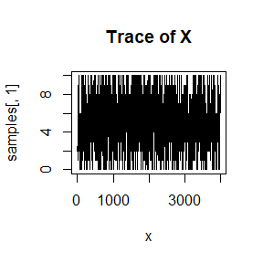

```r
# 绘制采样结果
plot(samples[,1], xlab = "x",  type = 'l', main = "Trace of X")
```

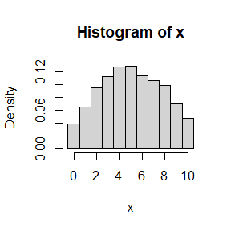

```r
hist(samples[,1], breaks = seq(-0.5, 10 + 0.5, by = 1), main = "Histogram of x", xlab = "x", probability = TRUE)
```

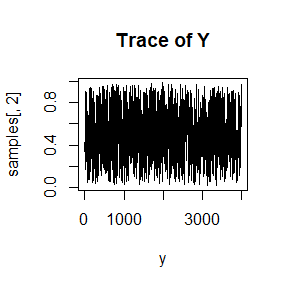

```r
plot(samples[,2], xlab = "y",  type = 'l', main = "Trace of Y")
```

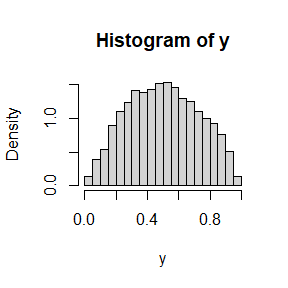

```r
hist(samples[,2], breaks = 30, main = "Histogram of y", xlab = "y", probability = TRUE)
```

### Question 2:

Compare the corresponding generated random numbers with those by the R function you wrote using the function “qqplot”.

### Answer for Question 2:

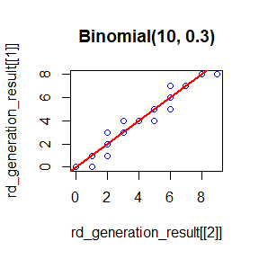

```r
set.seed(123) # 设置随机种子
N <- 4000 # 样本大小


rd_generation = function(n, a, b){
  #二项分布：Binomial(n, y),其中n=10,y=0.3
  binomial_s <- rbinom(N, size = n, prob = 0.3) # 生成二项分布随机数
  binomial_t <- qbinom(ppoints(N), size = n, prob = 0.3) # 生成理论分位数

  # 贝塔分布：Beta(x+a, n-x+b),其中x=5, n=10, a=b=2
  beta_s <- rbeta(N,  5+a, n-5+b) # 生成贝塔分布随机数
  beta_t <- qbeta(ppoints(N), 5+a, n-5+b) # 生成理论分位数

  return(list(binomial_s,binomial_t, beta_s, beta_t))
}

rd_generation_result = rd_generation(10,2,2)

# 绘制 二项分布的Q-Q 图
qqplot(rd_generation_result[[2]], rd_generation_result[[1]],
       main = "Binomial(10, 0.3)",col = "blue")
abline(0, 1, col = "red", lwd = 2) # 添加参考线
```

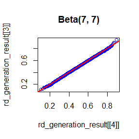

```r
# 绘制 贝塔分布Q-Q 图
qqplot(rd_generation_result[[4]], rd_generation_result[[3]],
       main = "Beta(7, 7)",col = "blue")
abline(0, 1, col = "red", lwd = 2) # 添加参考线
```

### Question 3:

Campare the computation time of the two functions with the function “microbenchmark”.

### ANswer for Question 3:

```r
library(Rcpp)
sourceCpp("C:/Users/36070/g1/tjjs/Homework-2024.11.18/gibbs_sampler.cpp")
library(microbenchmark)

ts = microbenchmark(ts_gibbs = gibbs_sampler(10,2,2), ts_rd = rd_generation(10,2,2))
summary(ts)
```

```
##       expr     min      lq      mean   median       uq     max neval
## 1 ts_gibbs  1.4653  1.6423  1.941709  1.76595  2.07195  5.3313   100
## 2    ts_rd 18.6477 20.2203 22.908594 22.04405 24.15835 44.2768   100
```

### Question 4:

Comment my results.

### Answer for Question 4:

一、分位数计算的差距

在绘制qqplot时，需要用到qbeta和qbinom函数，用数值法计算4000个样本的分位数，计算量较大。

而Gibbs采样法无需计算理论分位数，只涉及rbeta和rbinom函数，因此只需抽取样本，无需数值计算。

二、Gibbs采样的局部计算

Gibbs 采样是一种逐步生成样本的方法，当前迭代的样本值仅基于上一轮样本的值和条件分布。避免了直接生成大批量样本所需的矩阵计算或排序操作，计算量更小。

与直接使用 rbinom() 和 rbeta()每次生成整组数据相比，Gibbs采样更高效。